# R6Nomogram Basics

## Nomograms

Nomograms are a graphical representation of a model. For other than the simplest of models, nomograms can better explain what the model is doing, compared to just interpreting coefficients. Each predictor variable (and any interactions) is represented by a horizontal scale.

To use a nomogram to make predictions, you look up the value of the predictor on the scale, then go straight up to the top scale (called points) to identify the number of points. You do this for each of the predictors, then sum the points and look up that value on a scale at the bottom of the plot and use that to predict the response value.

With modern computers we no longer need nomograms to help with the calculations, but they are helpful for opening the black box of the model. Things like transformations, polynomials, or splines of a predictor variable can more easily be interpreted from the plot than from a table of coefficients. Link functions on the response can also be visualized from the plot. Read on for an example to see how these plots can help with interpretation and explanation of models.

This vignette covers the basics and some of the options for creating nomograms using the R6Nomogram package. The idea is to create an initial nomogram, then, since it is an R6 object, use the methods to try different changes and improvements until you produce a good looking nomogram (the first one will probably need improvement).

The automated step work well for models with a `predict` method that has a `terms` option, such as `lm` and `glm`. Another vignette will cover what to do if there is no predict method, or it does not predict terms.

## The Model

We first need a model to visualize. We will use the `mtcars` data set that comes with R and fit a model to predict `mpg` (miles per gallon).

A few of the potential predictors make more sense as categorical, rather than numeric, predictors, so we will make a copy of the data frame and change the variables to factors.

```r
mtcars2 <- mtcars
mtcars2$cyl <- factor(mtcars2$cyl)
mtcars2$gear <- factor(mtcars2$gear)
mtcars2$vs <- factor(mtcars2$vs, levels=0:1, labels=c("V", "S"))

fit <- glm(mpg ~ poly(wt, 2) + poly(disp,2) + cyl*gear + vs,
           data=mtcars2, family=gaussian(link="inverse"))
summary(fit)
```

```
Call:
glm(formula = mpg ~ poly(wt, 2) + poly(disp, 2) + cyl * gear +
    vs, family = gaussian(link = "inverse"), data = mtcars2)

Coefficients: (1 not defined because of singularities)
                Estimate Std. Error t value Pr(>|t|)
(Intercept)     0.062011   0.007766   7.985 1.72e-07 ***
poly(wt, 2)1    0.045970   0.022222   2.069   0.0525 .
poly(wt, 2)2    0.026467   0.015388   1.720   0.1017
poly(disp, 2)1  0.039702   0.036696   1.082   0.2928
poly(disp, 2)2 -0.032707   0.017188  -1.903   0.0723 .
cyl6           -0.014901   0.008848  -1.684   0.1085
cyl8           -0.009747   0.011208  -0.870   0.3954
gear4          -0.005664   0.005466  -1.036   0.3132
gear5          -0.010201   0.006419  -1.589   0.1285
vsS            -0.001406   0.003784  -0.372   0.7142
cyl6:gear4      0.014192   0.008044   1.764   0.0937 .
cyl8:gear4            NA         NA      NA       NA
cyl6:gear5      0.022982   0.011309   2.032   0.0564 .
cyl8:gear5      0.015078   0.010113   1.491   0.1524
---
Signif. codes:  0 '***' 0.001 '**' 0.01 '*' 0.05 '.' 0.1 ' ' 1

(Dispersion parameter for gaussian family taken to be 5.437256)

    Null deviance: 1126.05  on 31  degrees of freedom
Residual deviance:  103.31  on 19  degrees of freedom
AIC: 156.32

Number of Fisher Scoring iterations: 6
```

I do not claim that this is the best model (or even a good model) for predicting `mpg`, but it illustrates most of the features of `R6Nomogram`.

Think about trying to explain the model based on the above summary to a non-statistician.

Using `glm` with the `gaussian` family and the “inverse” link means that the model actually fits the reciprocal of `mpg`, gallons per mile instead of miles per gallon.

## First Plot

Since `glm` models are pretty straight forward, the automated parts of `R6Nomogram` will work directly, we just create a new object based on the model:

```r
library(R6Nomogram)

n1 <- R6Nomogram$new(fit)
```

```
1. Loading newdata
2. Populating Variables
3. Creating x varibles
4. Shifting x variables
5. Scaling x variables
6, Prettying x
   Pretyying y
Finishing
```

The steps taken are printed out. Since it finished we do not have to worry about anything. If there had been something tricky, then we would have seen which step the problem occurred on, rerun everything up to that step, and then manually did the rest.

Now we can call the `plot` method to see the first iteration of our plot (warning: this will not be pretty, we will improve it).

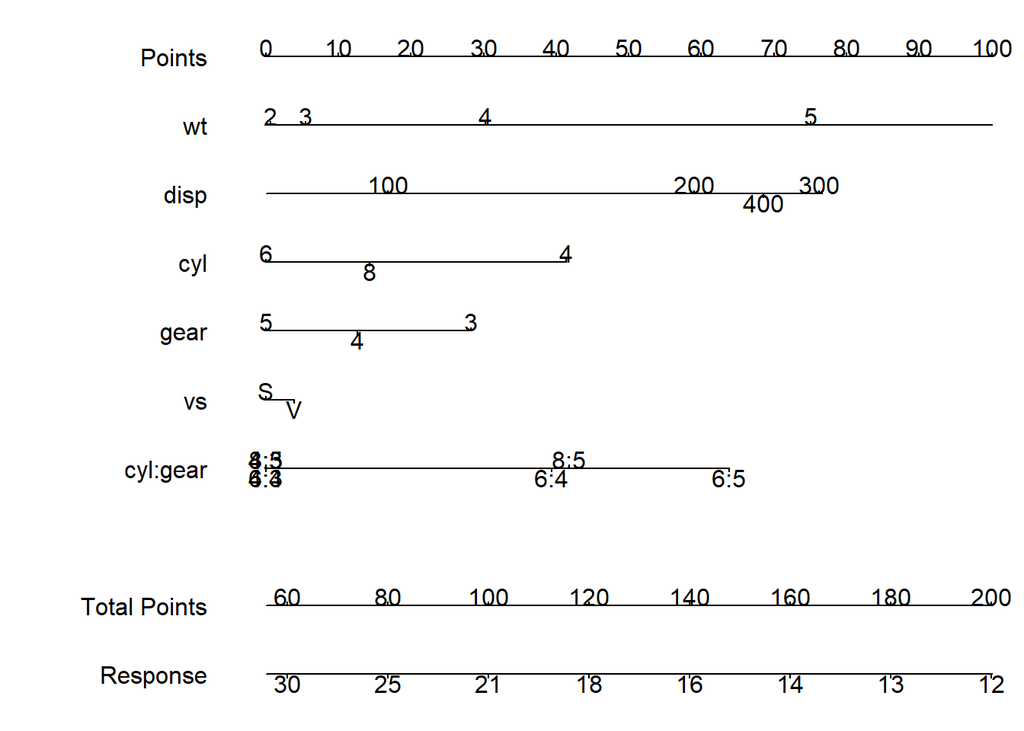

```r
n1$plot()
```

This gives the basic plot, we can start to see some of the patterns, but there are some labels plotted on top of each other and there are some big gaps. We can improve the plot.

## Total Points and Response

The default plot does not show the linear predictor. Sometimes it is distracting, but other times it can grant insight. In our model the linear predictor is the gallons per mile variable and can be interesting. We will tell it to plot the linear predictor and also change the label for it and the response. We need to set the field `v.pos.r` to `NULL` so that the correct positions are computed the next time we plot.

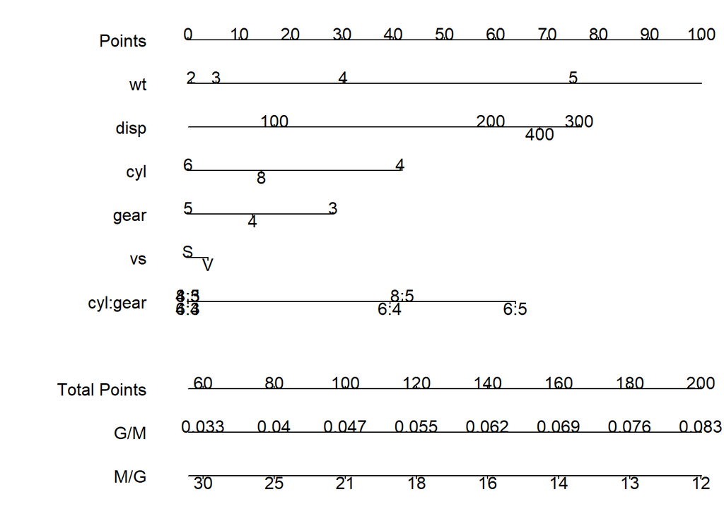

```r
n1$plot.lp <- TRUE
n1$v.pos.r <- NULL
n1$lp.lab <- "G/M"
n1$resp.lab <- "M/G"
n1$plot()
```

## Categorical Labels

Next we can see that there are several labels plotting on top of each other on the line for the interaction. This is because “4” is the baseline for `cyl` and “3” is the baseline for `gear`, so all the interactions including either of those all have the same value. We will replace one of the values with “Other” and the remaining ones with “” so that they will be blank.

```r
dput(n1$x.pretty.vals$`cyl:gear`)
```

```
c("4:3", "6:3", "8:3", "4:4", "6:4", "4:5", "6:5", "8:5")
```

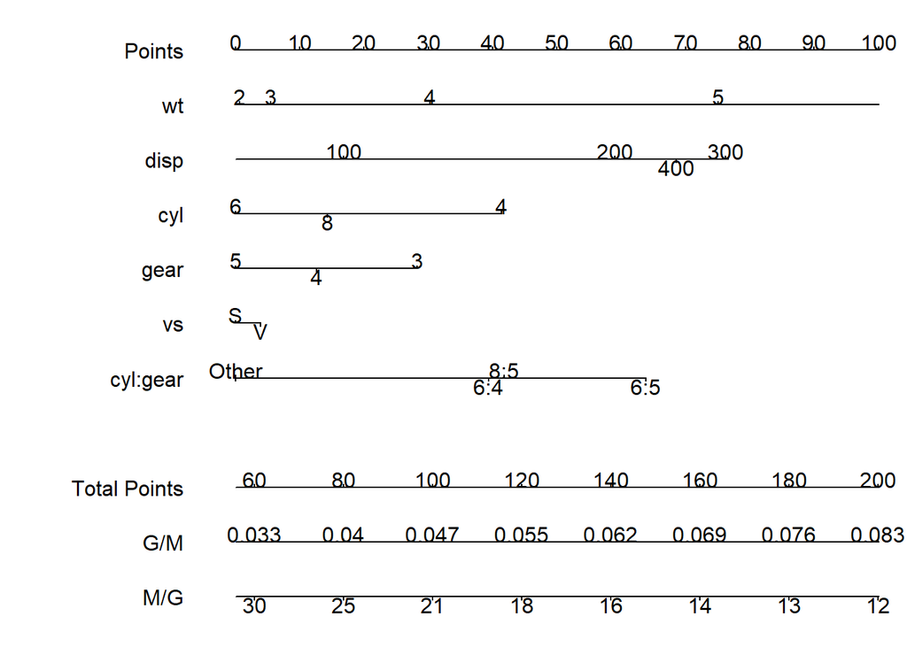

```r
n1$x.pretty.vals$`cyl:gear` <-
   c("Other", "", "", "", "6:4", "", "6:5", "8:5")
n1$plot()
```

## Tick Values

The values where to put the ticks was determined by the `pretty` and related functions, but they did not take into account the non-linearity. Some of the scales have large blank areas where it would make sense to put more tick marks and labels. Let’s take care of that now.

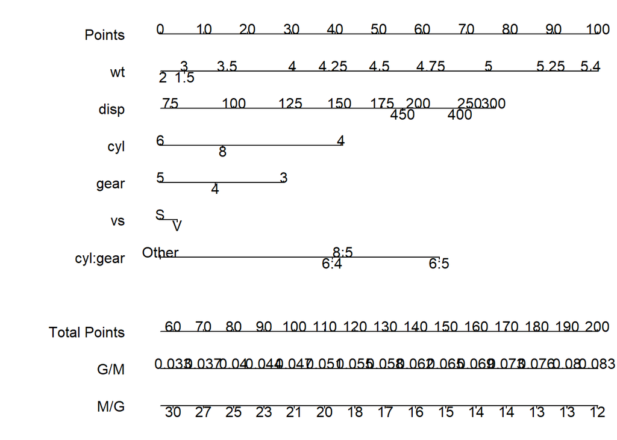

```r
n1$pretty.y(seq(60, 200, by=10))
n1$pretty('wt', c(1.5, 2, 3, 3.5, 4, 4.25, 4.5,
                 4.75, 5, 5.25, 5.4))
n1$pretty('disp', c(75, 100, 125, 150, 175, 200, 250,
                   300, 400, 450))
n1$plot()
```

## Additional Options

There is still overlap on the gallons per mile line, lets set some options to make these look better and also move all of the labels further from the lines and make the tick marks a little longer.

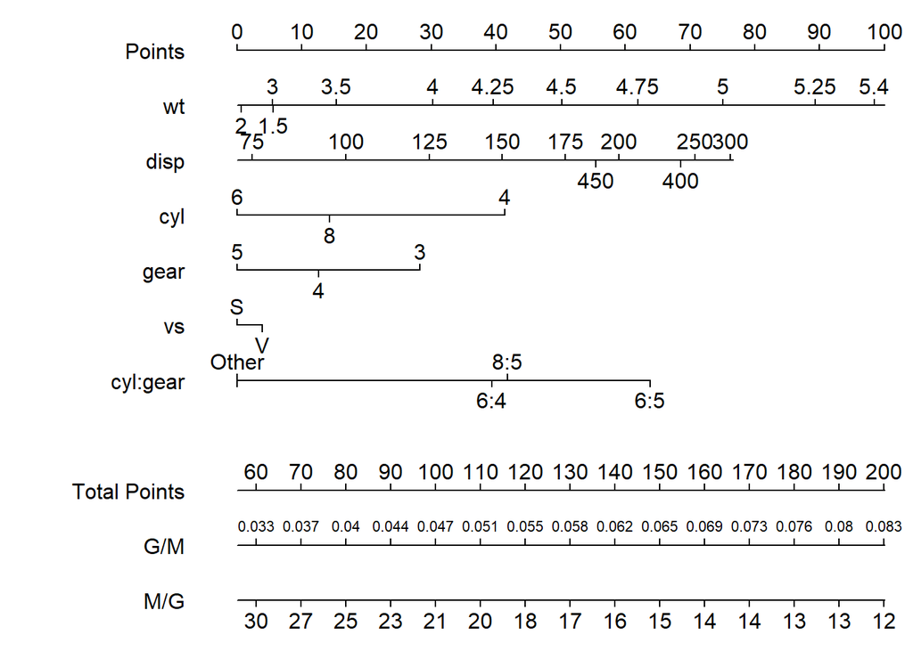

```r
n1$options$text.par[['linear predictor']] <- list(cex=0.7)
n1$options$tik.len <- 0.4
n1$options$txt.pos <- 1.2
n1$options$signif.digits <- 3
n1$plot()
```

Now it looks much better than when we started.

## Predictions

We can do one more thing, demonstrate the predictive idea by giving the `plot` method a row from our data (or a new, matching data frame).

```r
par(oma=c(0,0,1,0))
n1$plot(predict = mtcars2[1,])
```

```
cyl:gear :  39.39687
vs :  3.904236
gear :  12.59639
cyl :  0
disp :  45.10572
wt :  1.293572

Total Points:  102.2968
```

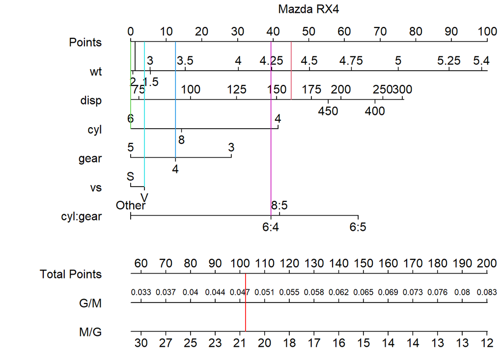

```r
mtext(rownames(mtcars2)[1], line=1)
```

```r
n1$plot(predict = mtcars2[20,])
```

```
cyl:gear :  0
vs :  0
gear :  12.59639
cyl :  41.36501
disp :  0
wt :  1.730594

Total Points:  55.69199
```

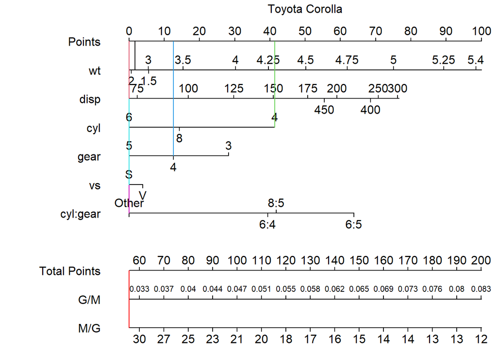

```r
mtext(rownames(mtcars2)[20], line=1)
```

```r
n1$plot(predict = mtcars2[15,])
```

```
cyl:gear :  0
vs :  3.904236
gear :  28.31842
cyl :  14.30722
disp :  47.63867
wt :  89.31539

Total Points:  183.4839
```

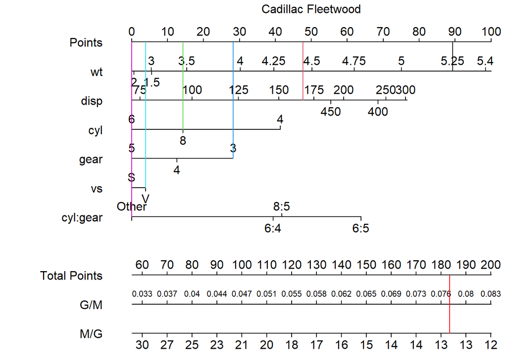

```r
mtext(rownames(mtcars2)[15], line=1)
```

## Tables

We can approximate the number of points from the graph and see a specific set of values when predicting. But, we may want to have tables with more values that we can look up.

Since we will probably want more dense values for the tables, but we do not want to mess up our plot, we will first clone the object, then redo the “tick” locations, then use the `table` method to show the tables. These tables can also be saved as a list so that they can be copied to a database or spreadsheet to use in other look-up tools.

```r
n2 <- n1$clone()

n2$pretty.y(seq(60, 200, by=5))
n2$pretty('wt', seq(1.5, 5.4, by=0.1))
n2$pretty('disp', seq(75, 450, by=25))
n2$tables()
```

```
$wt
    wt      Points
1  1.5  5.64567238
2  1.6  4.25317933
3  1.7  3.03549929
4  1.8  2.03406486
5  1.9  1.22862005
6  2.0  0.61905387
7  2.1  0.20997714
8  2.2  0.00000000
9  2.3 -0.01084037
10 2.4  0.17759976
11 2.5  0.56529554
12 2.6  1.15226545
13 2.7  1.93850353
```

[output cut: 106 more lines]